# December 14, 2016. updated 27 jan

Following previous notation, if we call $l(\theta;D^+)$ the -log-likelihood function of the complete phylogenetic tree we have a function that looks like this

$$l(\theta;D^+) = \sum n_i t_i - log(\rho_i)$$

If we focuss only on the influence of extinctions, and we assume constant extinction rate $\mu$, we can write this equation on the following way

$$l(\theta;D^+) = \sum (n_i t_i-E_i log(\lambda_i)) \color{blue}{ - (\#extinctions \cdot log(\mu)) }$$

Then, if $\mu < 1$ we would have that $l(\theta;D^+)$ increases with the number of extinctions the tree has (note that we want to minimaze $l(\theta;D^+)$).

This show us two anoying facts:

- Trees with less missing species have larger likelihood (if $\mu$<1)
- The model is time scale-dependent (the inflextion point $\mu$<1 as different meanings with different time-scales).

The following are just simples exercises that helps on understanding the relationship beween the number of extinctions and the likelihood of a tree, in the context of importance sampling.

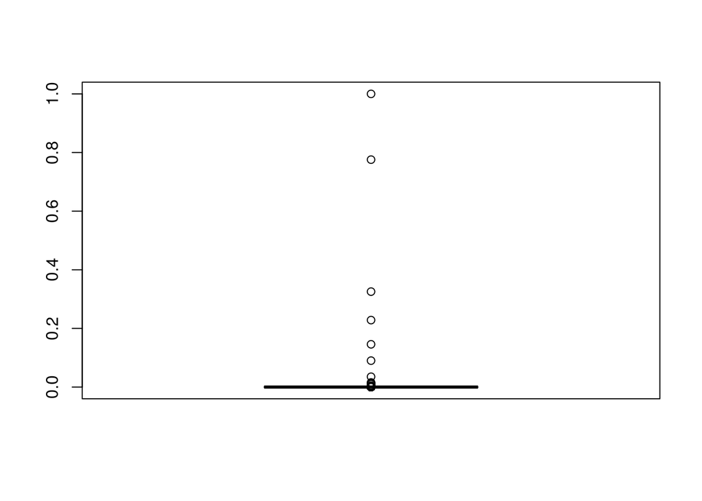

```r
num_miss = NULL
imp_scal = NULL
#g = NULL
#f = NULL
seed=2
st = sim_phyl(seed=seed)
extant = phylo2p(drop.fossil(st$newick))
pars=c(0.8,0.0175,0.1)
S = sim_srt(wt=extant$t, pars=pars, parallel=T, n_trees=1000)
for(i in 1:1000){
  imp_scal[i] = S[[i]]$weight
  #num_miss[i] = (length(rec$wt)-length(extant$t))/2
  #g[i] = rec$prob
  #f[i] = rec$f_n
}
#plot(num_miss,log(imp_scal))
boxplot(imp_scal)
```

```r
imp_scal
```

[output not shown]

```r
summary(imp_scal)
```

```
##    Min. 1st Qu.  Median    Mean 3rd Qu.    Max.
## 0.00000 0.00000 0.00000 0.01013 0.00000 1.00000
```

```r
#lm(log(imp_scal) ~ num_miss)
```